# Crime Classification - Binary Classification

March 29, 2020

```r
library(ggplot2)
require(gridExtra)
library(car)
library(factoextra)
library(dplyr)
library(DT)
library(knitr)
```

# Data Exploration

```r
df <- read.csv("https://raw.githubusercontent.com/mkivenson/Business-Analytics-Data-Mining/master/Classification%20Project/crime-training-data_modified.csv")
datatable(df)
```

|  | zn | indus | chas | nox | rm | age | dis | rad | tax | ptratio | lstat | medv | target |
| --- | --- | --- | --- | --- | --- | --- | --- | --- | --- | --- | --- | --- | --- |
| 1 | 0 | 19.58 | 0 | 0.605 | 7.929 | 96.2 | 2.0459 | 5 | 403 | 14.7 | 3.7 | 50 | 1 |
| 2 | 0 | 19.58 | 1 | 0.871 | 5.403 | 100 | 1.3216 | 5 | 403 | 14.7 | 26.82 | 13.4 | 1 |
| 3 | 0 | 18.1 | 0 | 0.74 | 6.485 | 100 | 1.9784 | 24 | 666 | 20.2 | 18.85 | 15.4 | 1 |
| 4 | 30 | 4.93 | 0 | 0.428 | 6.393 | 7.8 | 7.0355 | 6 | 300 | 16.6 | 5.19 | 23.7 | 0 |
| 5 | 0 | 2.46 | 0 | 0.488 | 7.155 | 92.2 | 2.7006 | 3 | 193 | 17.8 | 4.82 | 37.9 | 0 |
| 6 | 0 | 8.56 | 0 | 0.52 | 6.781 | 71.3 | 2.8561 | 5 | 384 | 20.9 | 7.67 | 26.5 | 0 |
| 7 | 0 | 18.1 | 0 | 0.693 | 5.453 | 100 | 1.4896 | 24 | 666 | 20.2 | 30.59 | 5 | 1 |
| 8 | 0 | 18.1 | 0 | 0.693 | 4.519 | 100 | 1.6582 | 24 | 666 | 20.2 | 36.98 | 7 | 1 |
| 9 | 0 | 5.19 | 0 | 0.515 | 6.316 | 38.1 | 6.4584 | 5 | 224 | 20.2 | 5.68 | 22.2 | 0 |
| 10 | 80 | 3.64 | 0 | 0.392 | 5.876 | 19.1 | 9.2203 | 1 | 315 | 16.4 | 9.25 | 20.9 | 0 |

[output cut: 456 more lines]

#### Summary

First, we take a look at a summary of the data. A few items of interest are revealed:

- There are no missing values in the dataset
- There are no immediately apparent outliers
- Expected clusters are of similar size (237 and 229). This is a necessary assumption for algorithms such as K-Means clustering.

```r
summary(df)
```

```
##        zn             indus             chas              nox
##  Min.   :  0.00   Min.   : 0.460   Min.   :0.00000   Min.   :0.3890
##  1st Qu.:  0.00   1st Qu.: 5.145   1st Qu.:0.00000   1st Qu.:0.4480
##  Median :  0.00   Median : 9.690   Median :0.00000   Median :0.5380
##  Mean   : 11.58   Mean   :11.105   Mean   :0.07082   Mean   :0.5543
##  3rd Qu.: 16.25   3rd Qu.:18.100   3rd Qu.:0.00000   3rd Qu.:0.6240
##  Max.   :100.00   Max.   :27.740   Max.   :1.00000   Max.   :0.8710
##        rm             age              dis              rad
##  Min.   :3.863   Min.   :  2.90   Min.   : 1.130   Min.   : 1.00
##  1st Qu.:5.887   1st Qu.: 43.88   1st Qu.: 2.101   1st Qu.: 4.00
##  Median :6.210   Median : 77.15   Median : 3.191   Median : 5.00
##  Mean   :6.291   Mean   : 68.37   Mean   : 3.796   Mean   : 9.53
##  3rd Qu.:6.630   3rd Qu.: 94.10   3rd Qu.: 5.215   3rd Qu.:24.00
##  Max.   :8.780   Max.   :100.00   Max.   :12.127   Max.   :24.00
##       tax           ptratio         lstat             medv
##  Min.   :187.0   Min.   :12.6   Min.   : 1.730   Min.   : 5.00
##  1st Qu.:281.0   1st Qu.:16.9   1st Qu.: 7.043   1st Qu.:17.02
##  Median :334.5   Median :18.9   Median :11.350   Median :21.20
##  Mean   :409.5   Mean   :18.4   Mean   :12.631   Mean   :22.59
##  3rd Qu.:666.0   3rd Qu.:20.2   3rd Qu.:16.930   3rd Qu.:25.00
##  Max.   :711.0   Max.   :22.0   Max.   :37.970   Max.   :50.00
##      target
##  Min.   :0.0000
##  1st Qu.:0.0000
##  Median :0.0000
##  Mean   :0.4914
##  3rd Qu.:1.0000
##  Max.   :1.0000
```

#### Boxplots

Next, we create boxplots of each of the features - color coded by the target variable. These boxplots reveal significant information about the predictor variables

- The `chas` dummy variable has most of its values at 0
- indus, zn, nox, age, dis, rad, tax, ptratio, lstat, and medv seem to have strong affects on the target variable

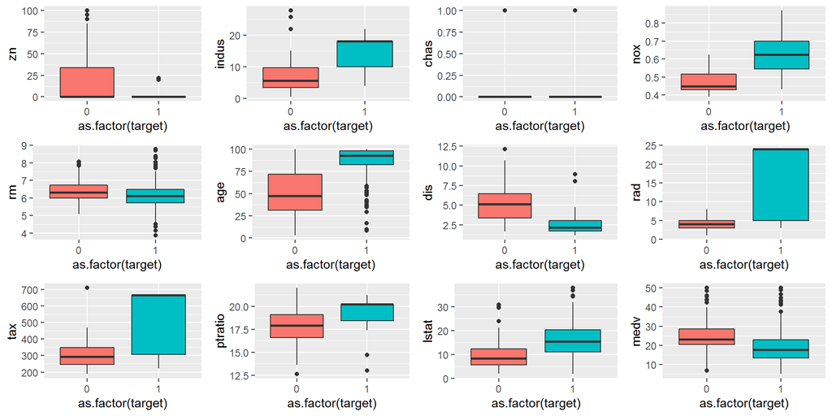

```r
grid.arrange(ggplot(df, aes(x = as.factor(target), y = zn, fill = as.factor(target))) + geom_boxplot() + theme(legend.position = "none") ,
             ggplot(df, aes(x = as.factor(target), y = indus, fill = as.factor(target))) + geom_boxplot() + theme(legend.position = "none") ,
             ggplot(df, aes(x = as.factor(target), y = chas, fill = as.factor(target))) + geom_boxplot() + theme(legend.position = "none") ,
             ggplot(df, aes(x = as.factor(target), y = nox, fill = as.factor(target))) + geom_boxplot() + theme(legend.position = "none") ,
             ggplot(df, aes(x = as.factor(target), y = rm, fill = as.factor(target))) + geom_boxplot() + theme(legend.position = "none") ,
             ggplot(df, aes(x = as.factor(target), y = age, fill = as.factor(target))) + geom_boxplot() + theme(legend.position = "none") ,
             ggplot(df, aes(x = as.factor(target), y = dis, fill = as.factor(target))) + geom_boxplot() + theme(legend.position = "none") ,
             ggplot(df, aes(x = as.factor(target), y = rad, fill = as.factor(target))) + geom_boxplot() + theme(legend.position = "none") ,
             ggplot(df, aes(x = as.factor(target), y = tax, fill = as.factor(target))) + geom_boxplot() + theme(legend.position = "none") ,
             ggplot(df, aes(x = as.factor(target), y = ptratio, fill = as.factor(target))) + geom_boxplot() + theme(legend.position = "none") ,
             ggplot(df, aes(x = as.factor(target), y = lstat, fill = as.factor(target))) + geom_boxplot() + theme(legend.position = "none") ,
             ggplot(df, aes(x = as.factor(target), y = medv, fill = as.factor(target))) + geom_boxplot() + theme(legend.position = "none") ,
             ncol=4)
```

#### PCA Component Visualization

PCA can be used for classification, but for now, it will be used to visualize the clusters. First, the number of components will be selected based on the variances explained by each component.

Taking a look at the plot of percentages explained by each principal component, it seems like most of the variance can be explained by 2 principal components.

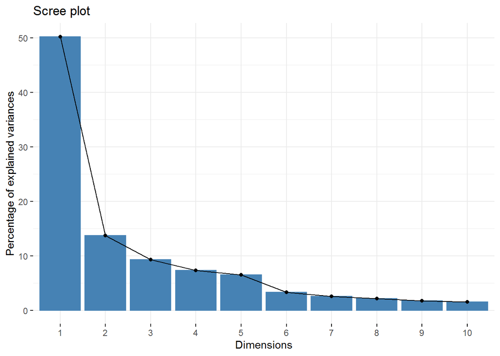

```r
df.pca <- prcomp(df[1:12], center = TRUE, scale. = TRUE)
fviz_eig(df.pca)
```

Using these two principal components, a scatterplot of the clusters can be created. Having two principal components makes it easier to distinguish between the two clusters, though there is some overlap.

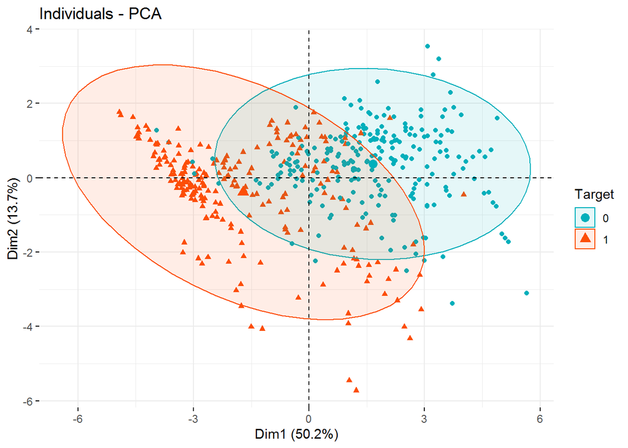

```r
fviz_pca_ind(df.pca,
             col.ind = as.factor(df$target), # Color by the quality of representation
             palette = c("#00AFBB",  "#FC4E07"),
             addEllipses = TRUE,
             legend.title = "Target",
             labels = FALSE
             )
```

# Data Preparation

Since the dataset does not have any missing values and there are no outliers that particulary stand out, data preparation will be limited. However, we will locate and address any influential outliers using Cooks Distance. Outliers that have a Cooks distance outside the acceptable threshold of 4 / (N - k - 1) where N is the number of observations and k is the number of predictive variables, will be removed.

#### Cooks Distance

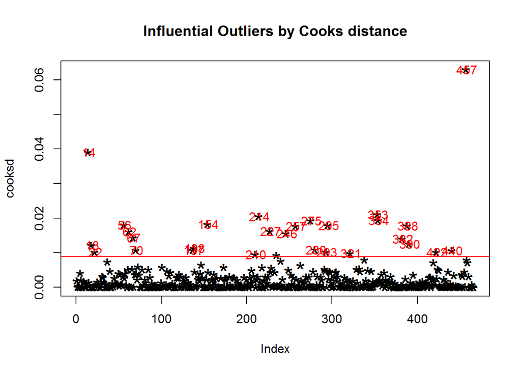

```r
mod <- lm(target ~ ., data=df)
cooksd <- cooks.distance(mod)
plot(cooksd, pch="*", cex=2, main="Influential Outliers by Cooks distance")
abline(h = 4 / (nrow(df) - ncol(df) - 1), col="red")  # add cutoff line
text(x=1:length(cooksd)+1, y=cooksd, labels=ifelse(cooksd>4*mean(cooksd, na.rm=T),names(cooksd),""), col="red")  # add labels
```

```r
influential <- as.numeric(names(cooksd)[(cooksd > 4 / (nrow(df) - ncol(df) - 1))])
df <- df[-influential, ]
```

## Building logistic regression

We will build a logistic classifer using generlized linear regresson with binomaial distribution.

Lets evaluate the distribution of target class label and check whether the dataset is imbalanced or not.

```r
table(df$target)
```

```
##
##   0   1
## 224 213
```

we see that both label 0 and label 1 is balanced and have nearly equal number of datapoints.

Now lets split the given data set into 80% of training data and 20% testing data. And build logistic classifer with the training set

```r
library(caTools)
library(pROC)
library(caret)
set.seed(123)
split = sample.split(df$target, SplitRatio = 0.8)
training_set = subset(df, split == TRUE)
test_set = subset(df, split == FALSE)

log_classifer <- glm(target ~ ., data = training_set, family = "binomial")
summary(log_classifer)
```

```
##
## Call:
## glm(formula = target ~ ., family = "binomial", data = training_set)
##
## Deviance Residuals:
##     Min       1Q   Median       3Q      Max
## -2.4671  -0.0494  -0.0004   0.0004   3.5381
##
## Coefficients:
##               Estimate Std. Error z value Pr(>|z|)
## (Intercept) -44.742177  10.761584  -4.158 3.22e-05 ***
## zn           -0.014315   0.045798  -0.313  0.75461
## indus         0.237724   0.159054   1.495  0.13502
## chas         -2.872278   3.055233  -0.940  0.34716
## nox          51.881443  12.562054   4.130 3.63e-05 ***
## rm           -0.301124   1.120871  -0.269  0.78820
## age           0.072289   0.023377   3.092  0.00199 **
## dis           0.469036   0.320498   1.463  0.14334
## rad           0.971234   0.296170   3.279  0.00104 **
## tax          -0.023633   0.008772  -2.694  0.00706 **
## ptratio       0.541119   0.211931   2.553  0.01067 *
## lstat        -0.030661   0.094303  -0.325  0.74508
## medv          0.112647   0.100988   1.115  0.26466
## ---
## Signif. codes:  0 '***' 0.001 '**' 0.01 '*' 0.05 '.' 0.1 ' ' 1
##
## (Dispersion parameter for binomial family taken to be 1)
##
##     Null deviance: 483.585  on 348  degrees of freedom
## Residual deviance:  96.733  on 336  degrees of freedom
## AIC: 122.73
##
## Number of Fisher Scoring iterations: 10
```

Above summary says there are very few independent variables are significant having p-value less than 0.05 Some of the significant Independent Variables are

- nox
- age
- rad
- tax
- ptratio

We will build another logistic classifier with these significant variables and compare the results with classifier with all variables.

Lets use the orginal logistic classifer to predict the test dataset. We will also plot an ROC graph and figure the best fit threshold for the classifier.

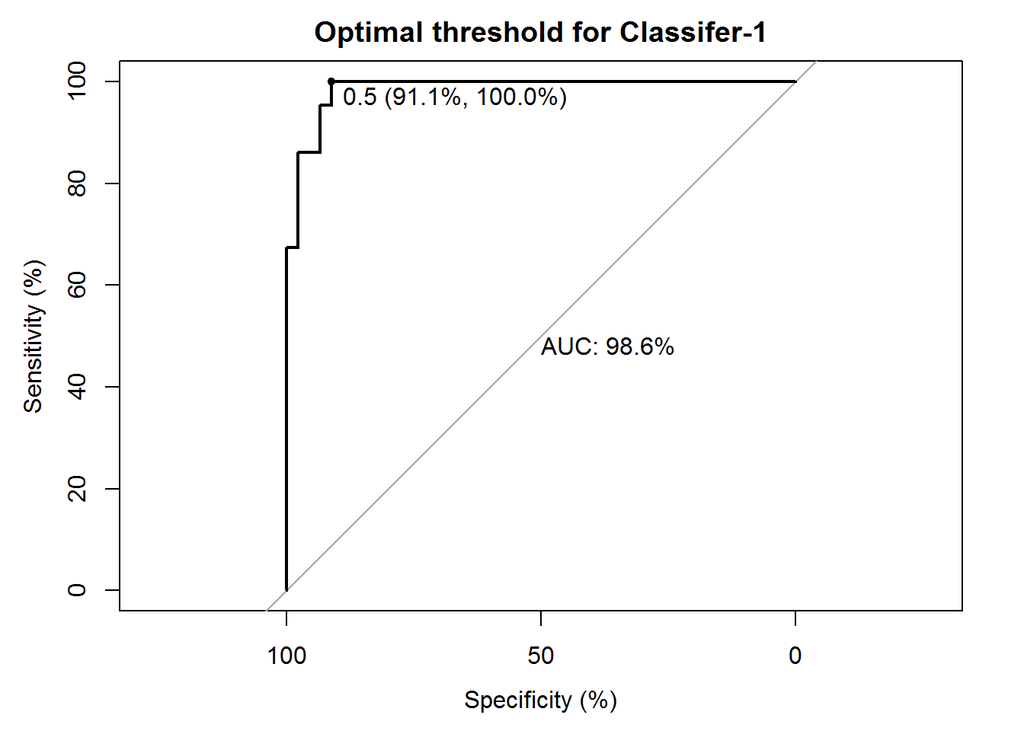

```r
result = predict(log_classifer, newdata = test_set, type = "response")
test_set$scored.probability1 <- result

plot.roc(test_set$target, test_set$scored.probability1,
main="Optimal threshold for Classifer-1", percent=TRUE, of="thresholds", # compute AUC (of threshold)
thresholds="best", # select the (best) threshold
print.auc = TRUE,
print.thres="best")
```

From the above ROC graph, we got the optimal threshold is 0.5. Lets use this threshold and print the confusion matrix and evaluate the preformance metric such as accuracy, Precision, Sensitivity.

```r
test_set$prediction1 <- ifelse(test_set$scored.probability1 > 0.5, 1, 0)
confusionMatrix(as.factor(test_set$prediction1),as.factor( test_set$target))
```

```
## Confusion Matrix and Statistics
##
##           Reference
## Prediction  0  1
##          0 41  0
##          1  4 43
##
##                Accuracy : 0.9545
##                  95% CI : (0.8877, 0.9875)
##     No Information Rate : 0.5114
##     P-Value [Acc > NIR] : <2e-16
##
##                   Kappa : 0.9092
##
##  Mcnemar's Test P-Value : 0.1336
##
##             Sensitivity : 0.9111
##             Specificity : 1.0000
##          Pos Pred Value : 1.0000
##          Neg Pred Value : 0.9149
##              Prevalence : 0.5114
##          Detection Rate : 0.4659
##    Detection Prevalence : 0.4659
##       Balanced Accuracy : 0.9556
##
##        'Positive' Class : 0
##
```

This classifer gives

- 95% Accuracy
- 100% Precision with No Type-1 Error(False Positive Error)
- 91% Sensitivity with minor Type-2 Error(False negative Error)
- 98.6% AUC(Area under Curve)

Lets build a classifer with significant independent variables.

```r
log_classifer1 <- glm(target ~ nox + age + rad + tax + ptratio, data = training_set, family = "binomial")
summary(log_classifer1)
```

```
##
## Call:
## glm(formula = target ~ nox + age + rad + tax + ptratio, family = "binomial",
##     data = training_set)
##
## Deviance Residuals:
##     Min       1Q   Median       3Q      Max
## -2.0987  -0.0381  -0.0005   0.0003   3.4890
##
## Coefficients:
##               Estimate Std. Error z value Pr(>|z|)
## (Intercept) -40.362585   7.845611  -5.145 2.68e-07 ***
## nox          57.952112  11.741424   4.936 7.99e-07 ***
## age           0.064163   0.017117   3.749 0.000178 ***
## rad           0.979399   0.256121   3.824 0.000131 ***
## tax          -0.023954   0.006699  -3.576 0.000349 ***
## ptratio       0.381221   0.143148   2.663 0.007742 **
## ---
## Signif. codes:  0 '***' 0.001 '**' 0.01 '*' 0.05 '.' 0.1 ' ' 1
##
## (Dispersion parameter for binomial family taken to be 1)
##
##     Null deviance: 483.58  on 348  degrees of freedom
## Residual deviance: 104.07  on 343  degrees of freedom
## AIC: 116.07
##
## Number of Fisher Scoring iterations: 9
```

The AIC value is reduced, but the residual deviance increased a bit compared to the previous model. Lets test predict and evaluate the preformance metrics of the new classifer.

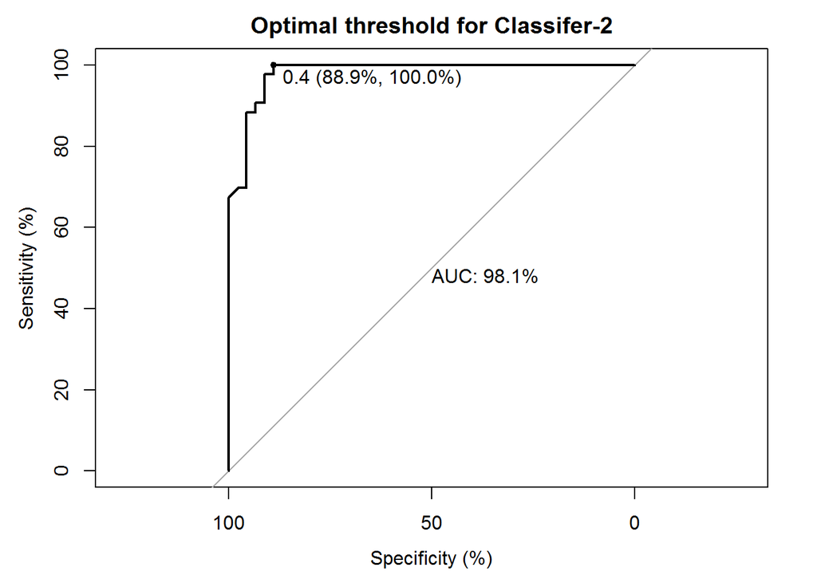

```r
result = predict(log_classifer1, newdata = test_set, type = "response")
test_set$scored.probability2 <- result

plot.roc(test_set$target, test_set$scored.probability2,
main="Optimal threshold for Classifer-2", percent=TRUE, of="thresholds", # compute AUC (of threshold)
thresholds="best", # select the (best) threshold
print.auc = TRUE,
print.thres="best")
```

```r
test_set$prediction1 <- ifelse(test_set$scored.probability1 > 0.4, 1, 0)
confusionMatrix(as.factor(test_set$prediction1),as.factor( test_set$target))
```

```
## Confusion Matrix and Statistics
##
##           Reference
## Prediction  0  1
##          0 40  0
##          1  5 43
##
##                Accuracy : 0.9432
##                  95% CI : (0.8724, 0.9813)
##     No Information Rate : 0.5114
##     P-Value [Acc > NIR] : < 2e-16
##
##                   Kappa : 0.8866
##
##  Mcnemar's Test P-Value : 0.07364
##
##             Sensitivity : 0.8889
##             Specificity : 1.0000
##          Pos Pred Value : 1.0000
##          Neg Pred Value : 0.8958
##              Prevalence : 0.5114
##          Detection Rate : 0.4545
##    Detection Prevalence : 0.4545
##       Balanced Accuracy : 0.9444
##
##        'Positive' Class : 0
##
```

This model gives

# Selection of the Best Model

Based on performance metrics such as AUC, Accuracy, Precisoion and Sensitiviy, the first classifer seems to be giving better results. We will use the first classifer and the threshold = 0.5 to predict for the evaluation data

```r
df_eval <- read.csv("https://raw.githubusercontent.com/mkivenson/Business-Analytics-Data-Mining/master/Classification%20Project/crime-evaluation-data_modified.csv")

result = predict(log_classifer, newdata = df_eval, type = "response")
df_eval$scored.probability <- result
df_eval$prediction <- ifelse(result > 0.5, 1, 0)

kable(df_eval)
```

| zn | indus | chas | nox | rm | age | dis | rad | tax | ptratio | lstat | medv | scored.probability | prediction |
| --- | --- | --- | --- | --- | --- | --- | --- | --- | --- | --- | --- | --- | --- |
| 0 | 7.07 | 0 | 0.469 | 7.185 | 61.1 | 4.9671 | 2 | 242 | 17.8 | 4.03 | 34.7 | 0.0109259 | 0 |
| 0 | 8.14 | 0 | 0.538 | 6.096 | 84.5 | 4.4619 | 4 | 307 | 21.0 | 10.26 | 18.2 | 0.7683939 | 1 |
| 0 | 8.14 | 0 | 0.538 | 6.495 | 94.4 | 4.4547 | 4 | 307 | 21.0 | 12.80 | 18.4 | 0.8501849 | 1 |
| 0 | 8.14 | 0 | 0.538 | 5.950 | 82.0 | 3.9900 | 4 | 307 | 21.0 | 27.71 | 13.2 | 0.4360758 | 0 |
| 0 | 5.96 | 0 | 0.499 | 5.850 | 41.5 | 3.9342 | 5 | 279 | 19.2 | 8.77 | 21.0 | 0.0264893 | 0 |
| 25 | 5.13 | 0 | 0.453 | 5.741 | 66.2 | 7.2254 | 8 | 284 | 19.7 | 13.15 | 18.7 | 0.3749295 | 0 |
| 25 | 5.13 | 0 | 0.453 | 5.966 | 93.4 | 6.8185 | 8 | 284 | 19.7 | 14.44 | 16.0 | 0.7011616 | 1 |
| 0 | 4.49 | 0 | 0.449 | 6.630 | 56.1 | 4.4377 | 3 | 247 | 18.5 | 6.53 | 26.6 | 0.0017325 | 0 |
| 0 | 4.49 | 0 | 0.449 | 6.121 | 56.8 | 3.7476 | 3 | 247 | 18.5 | 8.44 | 22.2 | 0.0008837 | 0 |
| 0 | 2.89 | 0 | 0.445 | 6.163 | 69.6 | 3.4952 | 2 | 276 | 18.0 | 11.34 | 21.4 | 0.0001323 | 0 |
| 0 | 25.65 | 0 | 0.581 | 5.856 | 97.0 | 1.9444 | 2 | 188 | 19.1 | 25.41 | 17.3 | 0.9987252 | 1 |
| 0 | 25.65 | 0 | 0.581 | 5.613 | 95.6 | 1.7572 | 2 | 188 | 19.1 | 27.26 | 15.7 | 0.9981869 | 1 |
| 0 | 21.89 | 0 | 0.624 | 5.637 | 94.7 | 1.9799 | 4 | 437 | 21.2 | 18.34 | 14.3 | 0.9932404 | 1 |
| 0 | 19.58 | 0 | 0.605 | 6.101 | 93.0 | 2.2834 | 5 | 403 | 14.7 | 9.81 | 25.0 | 0.9551789 | 1 |
| 0 | 19.58 | 0 | 0.605 | 5.880 | 97.3 | 2.3887 | 5 | 403 | 14.7 | 12.03 | 19.1 | 0.9401003 | 1 |
| 0 | 10.59 | 1 | 0.489 | 5.960 | 92.1 | 3.8771 | 4 | 277 | 18.6 | 17.27 | 21.7 | 0.0234977 | 0 |
| 0 | 6.20 | 0 | 0.504 | 6.552 | 21.4 | 3.3751 | 8 | 307 | 17.4 | 3.76 | 31.5 | 0.0691393 | 0 |
| 0 | 6.20 | 0 | 0.507 | 8.247 | 70.4 | 3.6519 | 8 | 307 | 17.4 | 3.95 | 48.3 | 0.9311122 | 1 |
| 22 | 5.86 | 0 | 0.431 | 6.957 | 6.8 | 8.9067 | 7 | 330 | 19.1 | 3.53 | 29.6 | 0.0020914 | 0 |
| 90 | 2.97 | 0 | 0.400 | 7.088 | 20.8 | 7.3073 | 1 | 285 | 15.3 | 7.85 | 32.2 | 0.0000001 | 0 |
| 80 | 1.76 | 0 | 0.385 | 6.230 | 31.5 | 9.0892 | 1 | 241 | 18.2 | 12.93 | 20.1 | 0.0000010 | 0 |
| 33 | 2.18 | 0 | 0.472 | 6.616 | 58.1 | 3.3700 | 7 | 222 | 18.4 | 8.93 | 28.4 | 0.1206934 | 0 |
| 0 | 9.90 | 0 | 0.544 | 6.122 | 52.8 | 2.6403 | 4 | 304 | 18.4 | 5.98 | 22.1 | 0.1202251 | 0 |
| 0 | 7.38 | 0 | 0.493 | 6.415 | 40.1 | 4.7211 | 5 | 287 | 19.6 | 6.12 | 25.0 | 0.0511290 | 0 |
| 0 | 7.38 | 0 | 0.493 | 6.312 | 28.9 | 5.4159 | 5 | 287 | 19.6 | 6.15 | 23.0 | 0.0266003 | 0 |
| 0 | 5.19 | 0 | 0.515 | 5.895 | 59.6 | 5.6150 | 5 | 224 | 20.2 | 10.56 | 18.5 | 0.6526216 | 1 |
| 80 | 2.01 | 0 | 0.435 | 6.635 | 29.7 | 8.3440 | 4 | 280 | 17.0 | 5.99 | 24.5 | 0.0000591 | 0 |
| 0 | 18.10 | 0 | 0.718 | 3.561 | 87.9 | 1.6132 | 24 | 666 | 20.2 | 7.12 | 27.5 | 1.0000000 | 1 |
| 0 | 18.10 | 1 | 0.631 | 7.016 | 97.5 | 1.2024 | 24 | 666 | 20.2 | 2.96 | 50.0 | 1.0000000 | 1 |
| 0 | 18.10 | 0 | 0.584 | 6.348 | 86.1 | 2.0527 | 24 | 666 | 20.2 | 17.64 | 14.5 | 0.9999996 | 1 |
| 0 | 18.10 | 0 | 0.740 | 5.935 | 87.9 | 1.8206 | 24 | 666 | 20.2 | 34.02 | 8.4 | 1.0000000 | 1 |
| 0 | 18.10 | 0 | 0.740 | 5.627 | 93.9 | 1.8172 | 24 | 666 | 20.2 | 22.88 | 12.8 | 1.0000000 | 1 |
| 0 | 18.10 | 0 | 0.740 | 5.818 | 92.4 | 1.8662 | 24 | 666 | 20.2 | 22.11 | 10.5 | 1.0000000 | 1 |
| 0 | 18.10 | 0 | 0.740 | 6.219 | 100.0 | 2.0048 | 24 | 666 | 20.2 | 16.59 | 18.4 | 1.0000000 | 1 |
| 0 | 18.10 | 0 | 0.740 | 5.854 | 96.6 | 1.8956 | 24 | 666 | 20.2 | 23.79 | 10.8 | 1.0000000 | 1 |
| 0 | 18.10 | 0 | 0.713 | 6.525 | 86.5 | 2.4358 | 24 | 666 | 20.2 | 18.13 | 14.1 | 1.0000000 | 1 |
| 0 | 18.10 | 0 | 0.713 | 6.376 | 88.4 | 2.5671 | 24 | 666 | 20.2 | 14.65 | 17.7 | 1.0000000 | 1 |
| 0 | 18.10 | 0 | 0.655 | 6.209 | 65.4 | 2.9634 | 24 | 666 | 20.2 | 13.22 | 21.4 | 1.0000000 | 1 |
| 0 | 9.69 | 0 | 0.585 | 5.794 | 70.6 | 2.8927 | 6 | 391 | 19.2 | 14.10 | 18.3 | 0.7743514 | 1 |
| 0 | 11.93 | 0 | 0.573 | 6.976 | 91.0 | 2.1675 | 1 | 273 | 21.0 | 5.64 | 23.9 | 0.8479228 | 1 |